# Summarizing and Visualizing Two Numeric Variables

# Scatter Plots

## Scatter Plots

**Definition: Scatter Plot**

Suppose you have a data matrix containing $n$ cases and numeric variables $x$ and $y$ measured on each case. A scatter plot for these two variables is simply a graph containing a circle or dot at each point $(x_i, y_i)$, so there is exactly one dot for each case in the data matrix.

## Scatter Plots

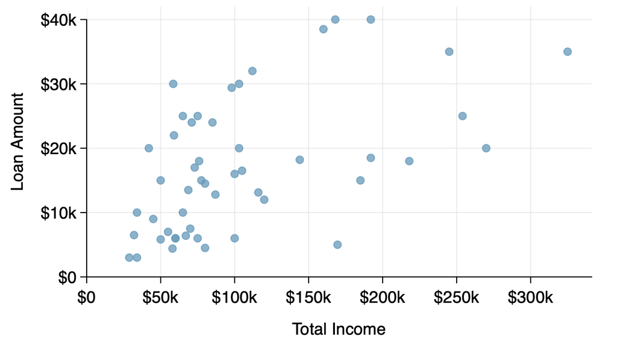

A Scatter Plot of Loan Amount Against Household Income

## Example: Coffee Shop

Sketch a scatter plot of Avg Wait vs Customers from this data matrix, showing data from a hypothetical coffee shop

| Date | Customers | Avg Spend ($) | Avg Wait (min) |
| --- | --- | --- | --- |
| 2026-03-02 | 87 | 7 | 4 |
| 2026-03-03 | 79 | 6 | 3 |
| 2026-03-04 | 94 | 7 | 3 |
| 2026-03-05 | 101 | 8 | 6 |
| 2026-03-06 | 118 | 9 | 5 |
| 2026-03-07 | 143 | 11 | 8 |

## Example: Coffee Shop

Your scatter plot should look like this:

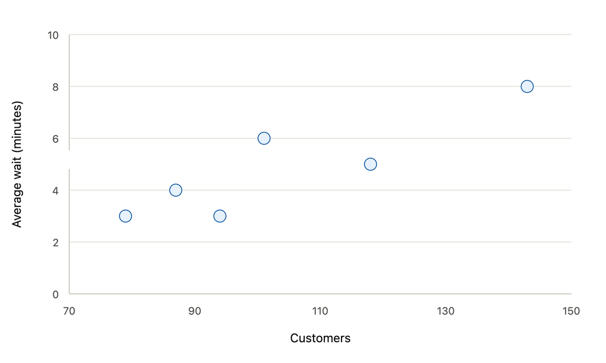

Scatter Plot of Avg Wait Versus Customers

## A Bigger Data Matrix

The same scatter plot showing more days of data:

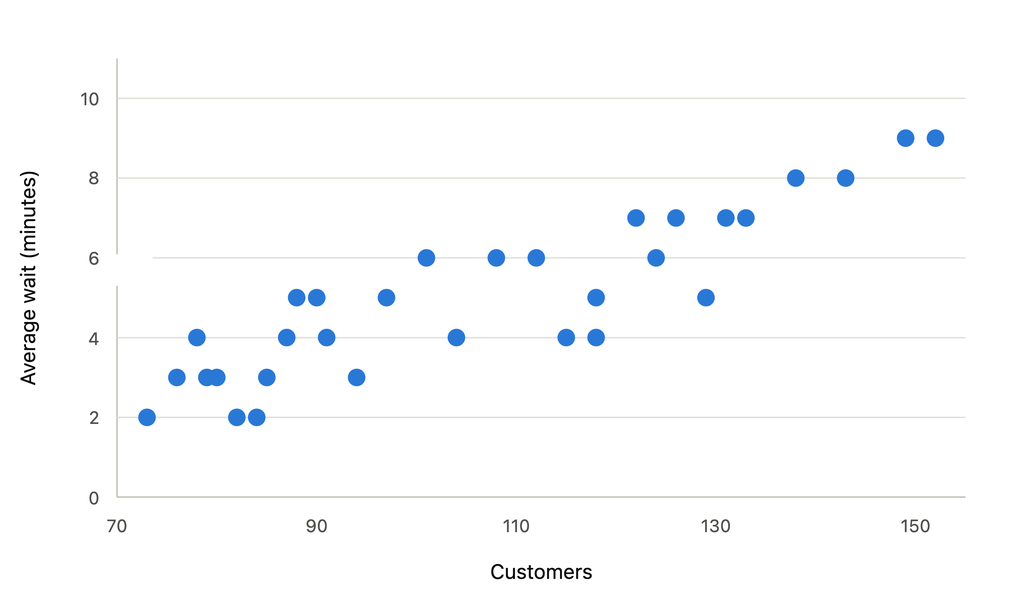

Scatter Plot of Avg Wait Versus Customers (More Data)

## Adding a Trend Line

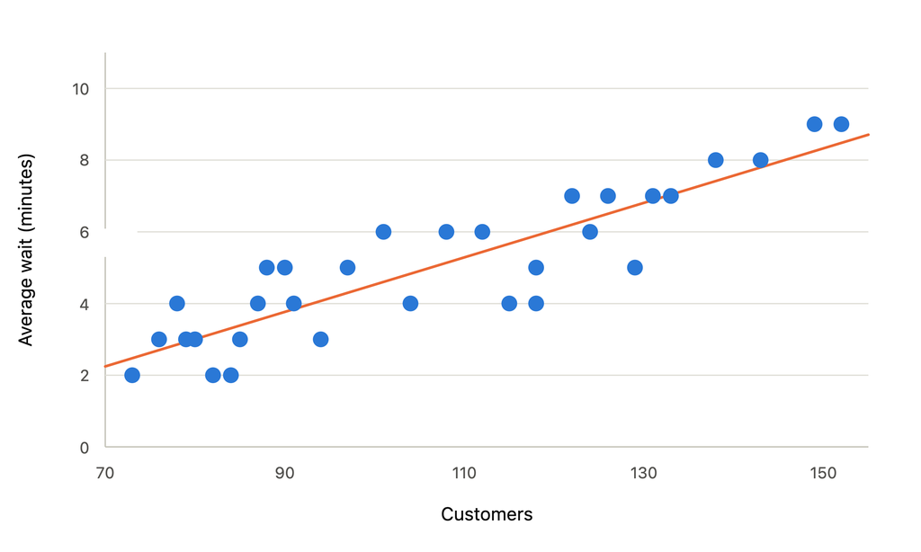

Scatter Plot of Avg Wait Versus Customers (More Data)

## Trend Lines

**Trends and Noise**

In the previous scatter plot, we saw that there was an upward **trend**: More customers are associated with longer waits.

We also saw that the trend is imperfect: The points are scattered around the trend line. We call this additional scattering **noise**.

The decomposition of data into **trend** plus **noise** is the *most important idea in statistics*.

# Trends and Regression

## Defining the Trend

**What is a trend?**

It is easy to sketch a trend line through data, but each person might sketch a slightly different line. In order to have objective measures of trend and noise, and in order to communicate clearly, we need a precise, objective definition of the trend line.

## Defining the Trend

**Step 1:** Equation for the trend.

**Equation for a line**

Recall that every line can be written using an **intercept** $a$ and a **slope** $b$:

$$y = a + bx$$

To define the trend line, we need to define $a$ and $b$.

## Defining the Trend

**Step 2:** Define the noise.

**Definition: Predictions and Residuals**

Let $x$ and $y$ be variables in a data matrix with trend line $y = a + bx$. For any value $x_i$ in the data matrix, we define the **predicted** value of $y$ by

$$\hat{y}_i = a+bx_i$$

The gap between the predicted and actual value of $y$ is called the **residual** and is defined by:

$$e_i = y_i - \hat{y}_i$$

## Predictions and Residuals

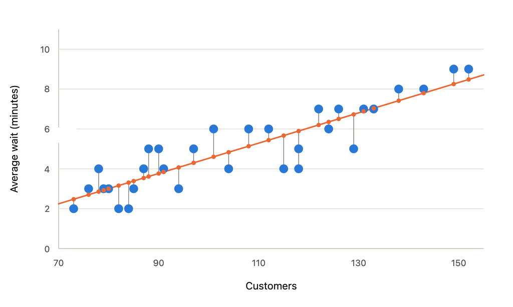

Scatter Plot with Predictions and Residuals

The grey vertical lines show the **residuals**

The orange dots on the line show the **predictions**

## A Note on Terminology

The predicted values $\hat{y}_i$ represent the **trend**.

The residuals represent the **noise**.

If there were no noise, we would have:

- **predicted** = **actual**
- **residuals** = 0

## Defining the Trend

**Step 3:** Minimize the residuals

**Rough Definition: Best Fit Line**

To define the trend line, we can ask for the line that *best fits the data*, meaning that the noise is as small as possible. This means we should try to minimize the size of the residuals for each predicted value.

## Detour: How Much Error?

**Warning**

We cannot minimize every residual simultaneously. A line that perfectly predicts the $y$ value of the first data point might do a horrible job predicting the second. Therefore, we want to make residuals small while balancing them across the whole dataset.

## Detour: How Much Error?

We can measure the error of a possible trend line $y=a + bx$ as the mean of squared residuals:

$$\frac{1}{n}\sum_{i=1}^n \left(y_i - \hat{y}_i\right)^2 = \frac{1}{n}\sum_{i=1}^n \left(y_i - (a + bx_i)\right)^2$$

## Defining the Trend

**Step 3:** Minimize the residuals

**Definition: Best Fit Line**

The **best fit line** is the line with intercept $a$ and slope $b$ that minimize the average squared residual, i.e.

$$\frac{1}{n}\sum_{i=1}^n \left(y_i - (a + bx_i)\right)^2$$

## The Best Fit Line: Notes

- Best fit line is the “closest” line to the data
- The best line is not necessarily a *good* line
  - Best fit line can have large average squared residual
  - This happens when $x$ does not explain $y$ well
- Best fit line is usually called the **regression line**

## Interpreting a Regression Line

Recall that the slope of a line is “rise over run”.

Suppose that $y = \$50,000 + \$175x$ is the regression line for
$$y = \text{ price of a house}, \quad x = \text{ square footage of a house}$$

Interpreting the slope:

$b=\$175$ means that, if house A has 100 more square feet than house B, then we expect house A to sell for

$$100 \times \$175 = \$17,500$$

more than house B.

## Interpreting a Regression Line

Suppose that $y = \$50,000 + \$175x$ is the regression line for
$$y = \text{ price of a house}, \quad x = \text{ square footage of a house}$$

Interpreting a prediction:

If a house has $2000$ square feet, then we predict it will sell for

$$\$50,000 + 2000 \times \$175 = \$400,000.$$

Because other factors contribute to sale value, this is only a prediction, not an exact computation.

We can interpret as: $\$400,000$ is what we think an **average** house with $2000$ square feet would sell for.

## Interpreting a Regression Line

Suppose that $y = \$50,000 + \$175x$ is the regression line for
$$y = \text{ price of a house}, \quad x = \text{ square footage of a house}$$

Interpreting a residual:

Suppose the sale price of a house has a residual of $\$10,000$, meaning that

$$y - \hat{y} = \text{actual sale price} - \text{predicted sale price} = \$10,000.$$

We can interpret this as: the house sold for $\$10,000$ more than what we would expect an average house of the same square footage to sell for.

## A Note on Nonlinearity

Sometimes the data has a trend that isn’t described well by a straight line:

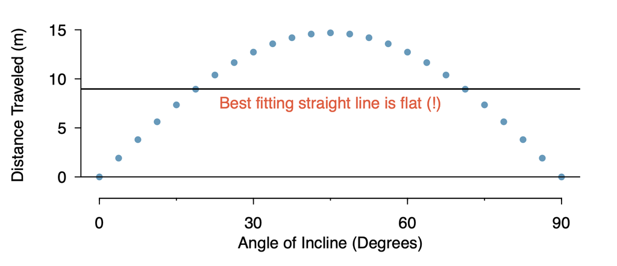

A nonlinear pattern in data

## A Note on Nonlinearity

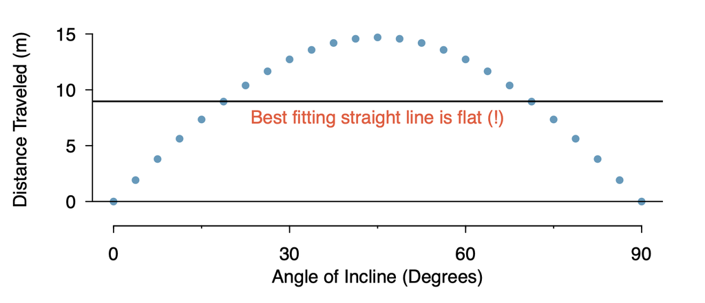

A nonlinear pattern in data

In this case, the best fitting line is **the wrong description of the data**.

People often fit lines to data without paying attention to whether a straight line is appropriate.

# Correlation

## Comparing Trend and Noise

Using a regression line $y = a + bx$, we can predict $y$ from $x$.

We may then want to quantify: How well does $x$ predict $y$?

## Comparing Trend and Noise

Another way to ask the same thing:

How strong is the trend relating $x$ and $y$ relative to the noise?

If there is zero noise, then $\hat{y}_i=y_i$ for all cases, and the predictions are perfect.

## Correlation

**Rough Definition: Correlation**

The correlation of $x$ and $y$ is a number between $-1$ and $1$ which measures two things:

1. How strong is the trend relating $x$ and $y$? Values closer to $1$ or $-1$ indicate strong trends, and values close to $0$ indicate weak trends.
2. Is the trend sloping upwards or downwards? Positive values indicate upward sloping trends, negative values downward sloping.

## Correlation: Strength of Trend

Recall the following notation:

$$\text{Predicted: } \hat{y}_i = a+bx_i$$

$$\text{Residual: } e_i = y_i - \hat{y}_i$$

## Correlation: Strength of Trend

Therefore, for every case:
$$y_i = \hat{y}_i + e_i$$

$$\text{Outcome} = \text{Predicted} + \text{Residual}$$

## Correlation: Strength of Trend

$$\text{Outcome} = \text{Predicted} + \text{Residual}$$

So, the variability in the outcome is the variability of the predictions plus the variability of the noise.

## Correlation: Strength of Trend

We can measure variability using the **standard deviation**

Variability of outcome: $s_y\quad \text{(SD of outcome)}$

Variability of predictions: $s_{\hat{y}} \quad \text{(SD of predictions)}$

Strength of trend: $s_{\hat{y}} / s_y$

## Correlation: Strength of Trend

Strength of trend can be measured by $s_{\hat{y}} / s_y$

**Discussion Question**

What happens to this measure if there is 0 noise, i.e. if every residual is 0?

## Correlation: Strength of Trend

Strength of trend can be measured by $s_{\hat{y}} / s_y$

**Discussion Question**

What happens to this measure if we keep the trend, i.e. the regression line, the same, but we make the noise/residuals larger?

## Correlation: Final Formula

The correlation between $x$ and $y$, written $r_{xy}$, is defined as
$$r_{xy} = \mathrm{sign}(b) \times \frac{s_{\hat{y}}}{s_y}$$

## Correlation: Final Formula

The correlation between $x$ and $y$, written $r_{xy}$, is defined as
$$r_{xy} = \underbrace{\mathrm{sign}(b)}_{\text{sign of slope: }\pm 1} \times \underbrace{\frac{s_{\hat{y}}}{s_y}}_{\text{strength of trend}}$$

## Visualizing Correlation

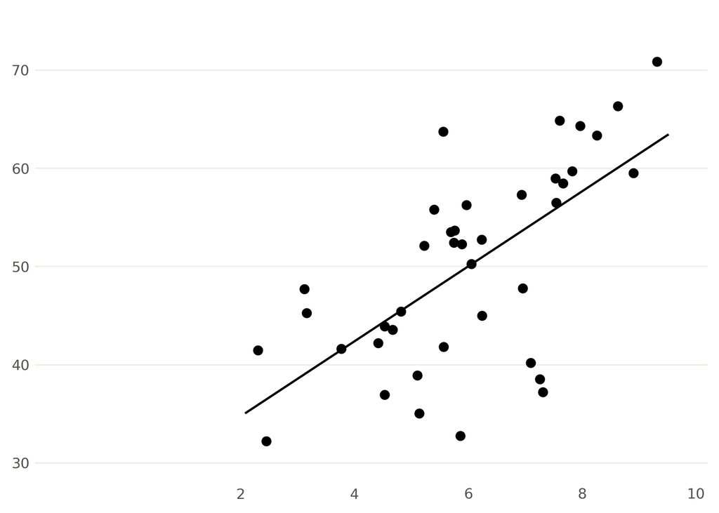

A scatter plot

## Visualizing Correlation

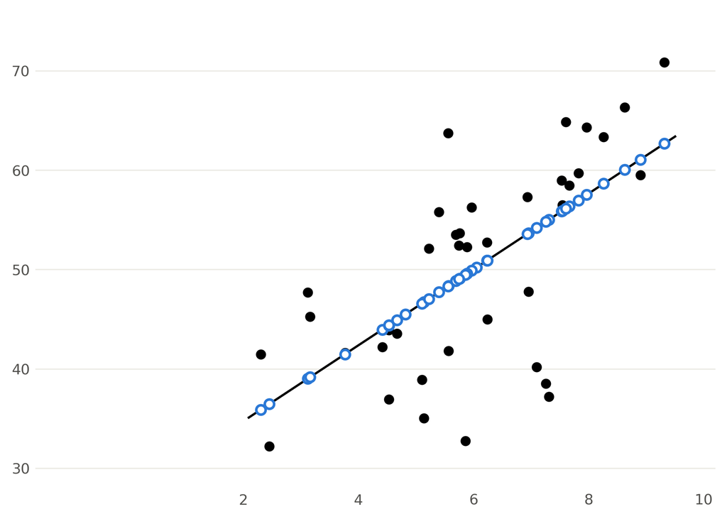

Scatter plot with predictions

## Visualizing Correlation

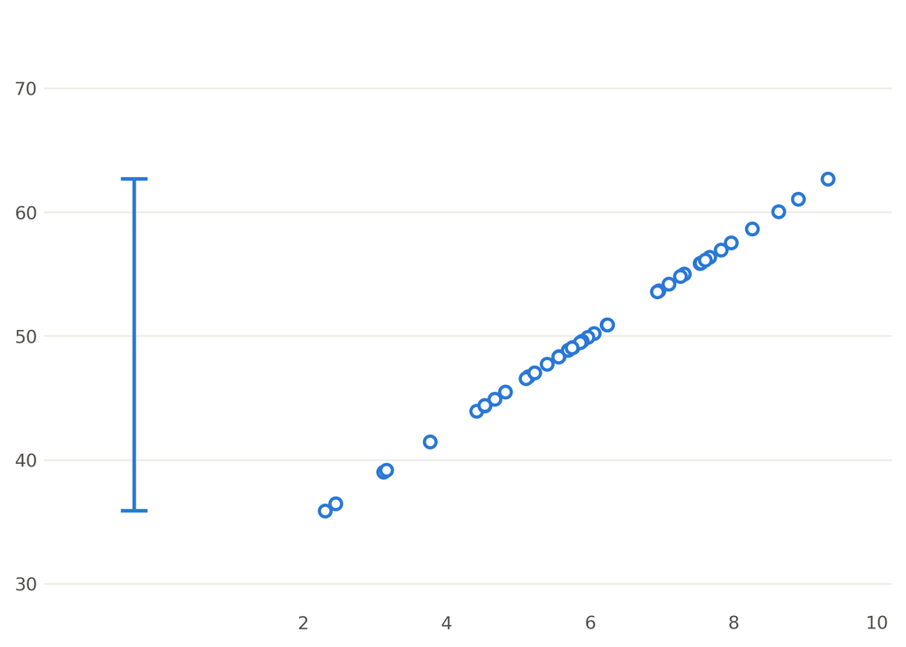

Predictions with their range shown

## Visualizing Correlation

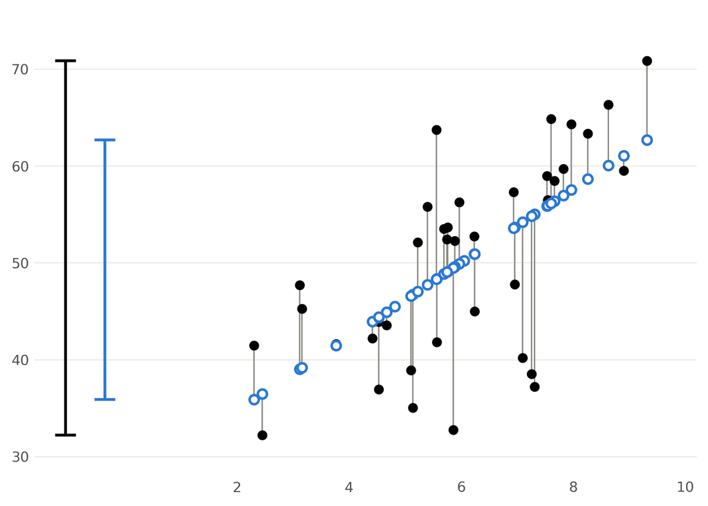

Predicted and actual points, with range of full data added (correlation $=0.65$)